# Bank stocks

```python
from pandas_datareader import data, wb
import pandas as pd
import numpy as np
import datetime
import seaborn as sns
%matplotlib inline
```

```python
start = datetime.datetime(2006,1,1)
end = datetime.datetime(2016,1,1)
BAC = data.DataReader('BAC','yahoo',start,end)
C = data.DataReader('C','yahoo',start,end)
GS = data.DataReader('GS','yahoo',start,end)
JPM = data.DataReader('JPM','yahoo',start,end)
MS = data.DataReader('MS','yahoo',start,end)
WFS = data.DataReader('WFC','yahoo',start,end)
```

[output not shown]

2517 rows × 6 columns

**Create a list of the ticker symbols (as strings) in alphabetical order. Call this list: tickers**

```python
tickers = ['BAC','C','GS','JMP','MS','WFS']
```

**Use pd.concat to concatenate the bank dataframes together to a single data frame called bank_stocks. Set the keys argument equal to the tickers list. Also pay attention to what axis you concatenate on.**

```python
bank_stocks = pd.concat([BAC,C,GS,JPM,MS,WFS],axis=1,keys = tickers)
bank_stocks.head()
```

| Date | BAC High | BAC Low | BAC Open | BAC Close | BAC Volume | BAC Adj Close | C High | C Low | C Open | C Close | ... | MS Open | MS Close | MS Volume | MS Adj Close | WFS High | WFS Low | WFS Open | WFS Close | WFS Volume | WFS Adj Close |
| --- | --- | --- | --- | --- | --- | --- | --- | --- | --- | --- | --- | --- | --- | --- | --- | --- | --- | --- | --- | --- | --- |
| 2006-01-03 | 47.180000 | 46.150002 | 46.919998 | 47.080002 | 16296700.0 | 34.596096 | 493.799988 | 481.100006 | 490.000000 | 492.899994 | ... | 57.169998 | 58.310001 | 5377000.0 | 36.786667 | 31.975000 | 31.195000 | 31.600000 | 31.900000 | 11016400.0 | 20.658106 |
| 2006-01-04 | 47.240002 | 46.450001 | 47.000000 | 46.580002 | 17757900.0 | 34.228691 | 491.000000 | 483.500000 | 488.600006 | 483.799988 | ... | 58.700001 | 58.349998 | 7977800.0 | 36.811905 | 31.820000 | 31.365000 | 31.799999 | 31.530001 | 10870000.0 | 20.418499 |
| 2006-01-05 | 46.830002 | 46.320000 | 46.580002 | 46.639999 | 14970700.0 | 34.272778 | 487.799988 | 484.000000 | 484.399994 | 486.200012 | ... | 58.549999 | 58.509998 | 5778000.0 | 36.912865 | 31.555000 | 31.309999 | 31.500000 | 31.495001 | 10158000.0 | 20.395836 |
| 2006-01-06 | 46.910000 | 46.349998 | 46.799999 | 46.570000 | 12599800.0 | 34.221321 | 489.000000 | 482.000000 | 488.799988 | 486.200012 | ... | 58.770000 | 58.570000 | 6889800.0 | 36.950710 | 31.775000 | 31.385000 | 31.580000 | 31.680000 | 8403800.0 | 20.515644 |
| 2006-01-09 | 46.970001 | 46.360001 | 46.720001 | 46.599998 | 15619400.0 | 34.243366 | 487.399994 | 483.000000 | 486.000000 | 483.899994 | ... | 58.630001 | 59.189999 | 4144500.0 | 37.341850 | 31.825001 | 31.555000 | 31.674999 | 31.674999 | 5619600.0 | 20.512400 |

5 rows × 36 columns

**Set the column name levels (this is filled out for you):**

```python
bank_stocks.columns.names = ['Bank Ticker','Stock Info']
bank_stocks.head()
```

| Bank Ticker Stock Info Date | BAC High | BAC Low | BAC Open | BAC Close | BAC Volume | BAC Adj Close | C High | C Low | C Open | C Close | ... | MS Open | MS Close | MS Volume | MS Adj Close | WFS High | WFS Low | WFS Open | WFS Close | WFS Volume | WFS Adj Close |
| --- | --- | --- | --- | --- | --- | --- | --- | --- | --- | --- | --- | --- | --- | --- | --- | --- | --- | --- | --- | --- | --- |
| 2006-01-03 | 47.180000 | 46.150002 | 46.919998 | 47.080002 | 16296700.0 | 34.596096 | 493.799988 | 481.100006 | 490.000000 | 492.899994 | ... | 57.169998 | 58.310001 | 5377000.0 | 36.786667 | 31.975000 | 31.195000 | 31.600000 | 31.900000 | 11016400.0 | 20.658106 |
| 2006-01-04 | 47.240002 | 46.450001 | 47.000000 | 46.580002 | 17757900.0 | 34.228691 | 491.000000 | 483.500000 | 488.600006 | 483.799988 | ... | 58.700001 | 58.349998 | 7977800.0 | 36.811905 | 31.820000 | 31.365000 | 31.799999 | 31.530001 | 10870000.0 | 20.418499 |
| 2006-01-05 | 46.830002 | 46.320000 | 46.580002 | 46.639999 | 14970700.0 | 34.272778 | 487.799988 | 484.000000 | 484.399994 | 486.200012 | ... | 58.549999 | 58.509998 | 5778000.0 | 36.912865 | 31.555000 | 31.309999 | 31.500000 | 31.495001 | 10158000.0 | 20.395836 |
| 2006-01-06 | 46.910000 | 46.349998 | 46.799999 | 46.570000 | 12599800.0 | 34.221321 | 489.000000 | 482.000000 | 488.799988 | 486.200012 | ... | 58.770000 | 58.570000 | 6889800.0 | 36.950710 | 31.775000 | 31.385000 | 31.580000 | 31.680000 | 8403800.0 | 20.515644 |
| 2006-01-09 | 46.970001 | 46.360001 | 46.720001 | 46.599998 | 15619400.0 | 34.243366 | 487.399994 | 483.000000 | 486.000000 | 483.899994 | ... | 58.630001 | 59.189999 | 4144500.0 | 37.341850 | 31.825001 | 31.555000 | 31.674999 | 31.674999 | 5619600.0 | 20.512400 |

5 rows × 36 columns

**Check the head of the bank_stocks dataframe.**

# EDA

Let's explore the data a bit! Before continuing, I encourage you to check out the documentation on [Multi-Level Indexing](http://pandas.pydata.org/pandas-docs/stable/advanced.html) and [Using .xs](http://pandas.pydata.org/pandas-docs/stable/generated/pandas.DataFrame.xs.html). Reference the solutions if you can not figure out how to use .xs(), since that will be a major part of this project.

**What is the max Close price for each bank's stock throughout the time period?**

**Create a new empty DataFrame called returns. This dataframe will contain the returns for each bank's stock. returns are typically defined by:**

$$r_t = \frac{p_t - p_{t-1}}{p_{t-1}} = \frac{p_t}{p_{t-1}} - 1$$

```python
for tick in tickers:
    print(bank_stocks[tick]['Close'].max())
```

```
54.900001525878906
564.0999755859375
247.9199981689453
70.08000183105469
89.30000305175781
58.52000045776367
```

**We can use pandas pct_change() method on the Close column to create a column representing this return value. Create a for loop that goes and for each Bank Stock Ticker creates this returns column and set's it as a column in the returns DataFrame.**

```python
returns = pd.DataFrame()
for tick in tickers:
    returns[tick+' Return'] = bank_stocks[tick]['Close'].pct_change()
```

**Create a pairplot using seaborn of the returns dataframe. What stock stands out to you? Can you figure out why?**

```python
returns.head()
```

| Date | BAC Return | C Return | GS Return | JMP Return | MS Return | WFS Return |
| --- | --- | --- | --- | --- | --- | --- |
| 2006-01-03 | NaN | NaN | NaN | NaN | NaN | NaN |
| 2006-01-04 | -0.010620 | -0.018462 | -0.013812 | -0.014183 | 0.000686 | -0.011599 |
| 2006-01-05 | 0.001288 | 0.004961 | -0.000393 | 0.003029 | 0.002742 | -0.001110 |
| 2006-01-06 | -0.001501 | 0.000000 | 0.014169 | 0.007046 | 0.001025 | 0.005874 |
| 2006-01-09 | 0.000644 | -0.004731 | 0.012030 | 0.016242 | 0.010586 | -0.000158 |

- See solution for details about Citigroup behavior....

**Using this returns DataFrame, figure out on what dates each bank stock had the best and worst single day returns. You should notice that 4 of the banks share the same day for the worst drop, did anything significant happen that day?**

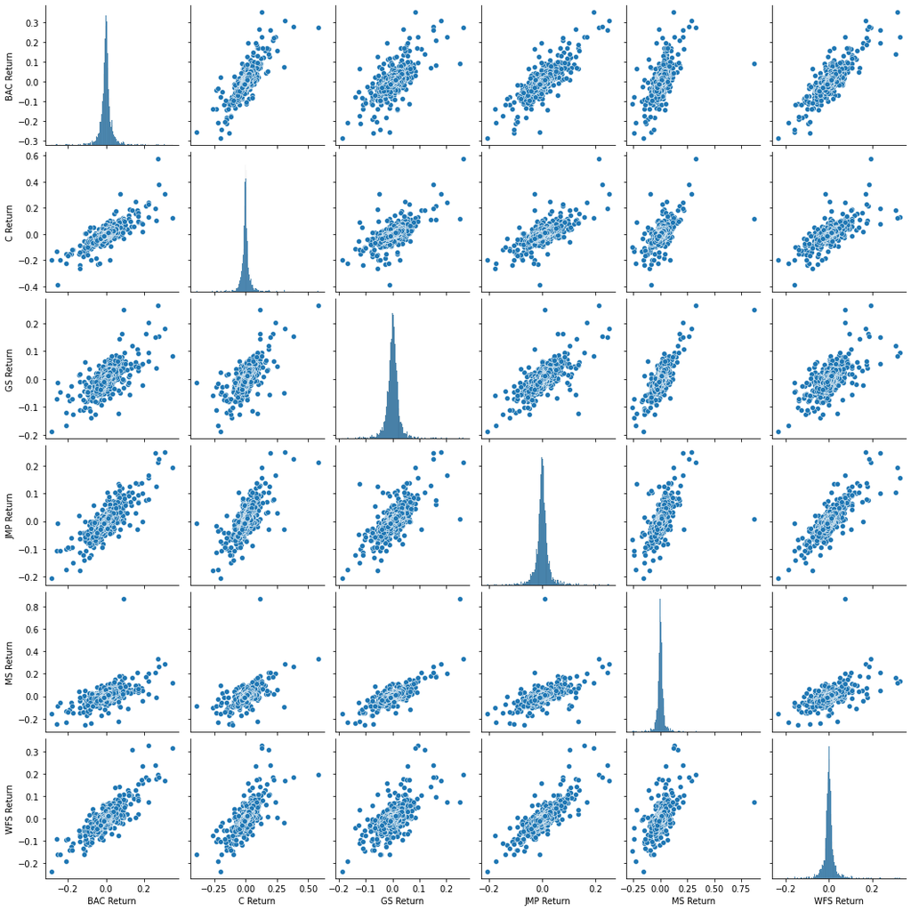

```python
sns.pairplot(returns[1:])
```

**You should have noticed that Citigroup's largest drop and biggest gain were very close to one another, did anythign significant happen in that time frame?**

- See Solution for details

```python
returns.idxmin()
returns.idxmax()
```

[output not shown]

```python
returns.loc['2015-01-01':'2015-12-31']
```

| Date | BAC Return | C Return | GS Return | JMP Return | MS Return | WFS Return |
| --- | --- | --- | --- | --- | --- | --- |
| 2015-01-02 | 0.000559 | 0.002772 | 0.002992 | -0.001438 | -0.002320 | -0.002189 |
| 2015-01-05 | -0.029050 | -0.031515 | -0.031223 | -0.031045 | -0.031258 | -0.027422 |
| 2015-01-06 | -0.029919 | -0.035205 | -0.020229 | -0.025929 | -0.028800 | -0.020865 |
| 2015-01-07 | 0.004745 | 0.009270 | 0.014903 | 0.001526 | 0.014278 | 0.005951 |
| 2015-01-08 | 0.020661 | 0.015048 | 0.015965 | 0.022346 | 0.014889 | 0.022137 |
| ... | ... | ... | ... | ... | ... | ... |
| 2015-12-24 | -0.004037 | 0.001520 | -0.002624 | -0.001948 | -0.003681 | -0.003997 |
| 2015-12-28 | -0.008107 | -0.006261 | -0.004658 | -0.003303 | -0.009544 | -0.002554 |
| 2015-12-29 | 0.008757 | 0.011455 | 0.010516 | 0.010395 | 0.011812 | 0.011156 |
| 2015-12-30 | -0.013310 | -0.012835 | -0.008282 | -0.007157 | -0.009831 | -0.007235 |
| 2015-12-31 | -0.012903 | -0.010516 | -0.009780 | -0.008410 | -0.013031 | -0.009656 |

252 rows × 6 columns

**Create a distplot using seaborn of the 2015 returns for Morgan Stanley**

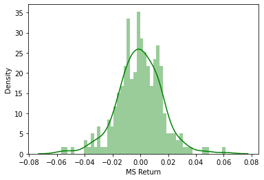

```python
sns.distplot(returns.loc['2015-01-01':'2015-12-31']['MS Return'],color='green',bins=50)
```

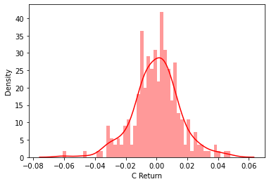

```python
sns.distplot(returns.loc['2015-01-01':'2015-12-31']['C Return'],color='red',bins=50)
```

```python
import matplotlib.pyplot as plt
import seaborn as sns
sns.set_style('whitegrid')
%matplotlib inline

# Optional Plotly Method Imports
import plotly
import cufflinks as cf
cf.go_offline()
```

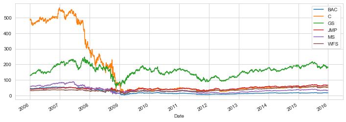

```python
for tick in tickers:
    bank_stocks[tick]['Close'].plot(label=tick,figsize=(12,4))
plt.legend()
```

```python
bank_stocks.xs(key='Close',axis=1,level='Stock Info').iplot()
```

[interactive chart not shown]

## Moving Averages

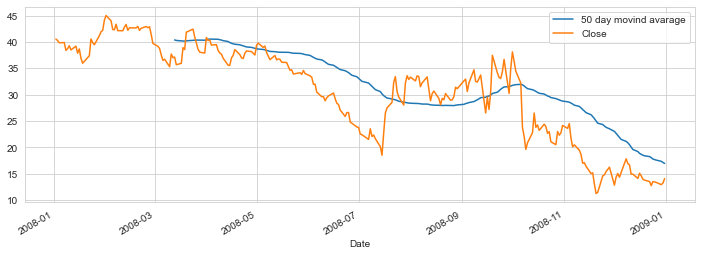

```python
plt.figure(figsize=(12,4))
BAC['Close'].loc['2008-01-01':'2009-01-01'].rolling(window=50).mean().plot(label='50 day movind avarage')
BAC['Close'].loc['2008-01-01':'2009-01-01'].plot(label='Close')
plt.legend()
```

# Part 2 (Optional)

In this second part of the project we will rely on the cufflinks library to create some Technical Analysis plots. This part of the project is experimental due to its heavy reliance on the cuffinks project, so feel free to skip it if any functionality is broken in the future.

**Use .iplot(kind='candle) to create a candle plot of Bank of America's stock from Jan 1st 2015 to Jan 1st 2016.**

```python
BAC2015=BAC[['Open','High','Low','Close']].loc['2015-01-01':'2016-01-01']
BAC2015.iplot(kind='candle')
```

[interactive chart not shown]

**Use .ta_plot(study='sma') to create a Simple Moving Averages plot of Morgan Stanley for the year 2015.**

```python
MS['Close'].loc['2015-01-01':'2016-01-01'].ta_plot(study='sma',periods=[13,21,55])
```

[interactive chart not shown]

```python
MS['Close'].loc['2015-01-01':'2016-01-01'].ta_plot(study='boll')
```

[interactive chart not shown]